# FIA Data Review

## BDF Data Analysis

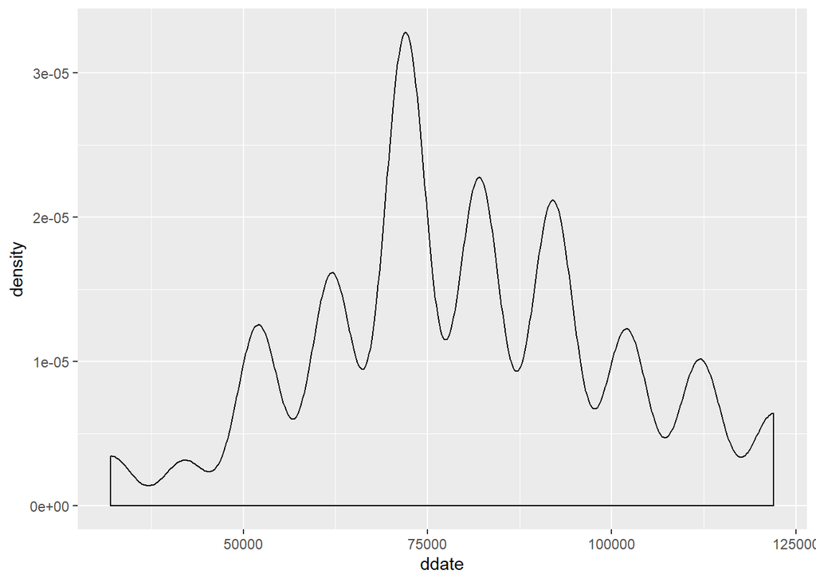

### BDF Conifer Count

| species | n |
| --- | --- |
| ABCO | 353 |
| CADE27 | 72 |
| PICO | 69 |
| PICO3 | 59 |
| PIJE | 270 |
| PILA | 116 |
| PIPO | 23 |
| PSMA | 34 |

### BDF Trees per Plot

| plot | n |
| --- | --- |
| 6 | 6 |
| 18 | 7 |
| 21 | 2 |
| 24 | 13 |
| 25 | 1 |
| 27 | 9 |
| 28 | 2 |
| 29 | 15 |
| 30 | 9 |
| 33 | 24 |
| 34 | 17 |
| 36 | 6 |
| 39 | 9 |
| 40 | 11 |
| 41 | 5 |
| 46 | 11 |
| 50 | 2 |
| 60 | 19 |
| 61 | 7 |
| 65 | 8 |
| 70 | 1 |
| 78 | 3 |
| 80 | 8 |
| 82 | 13 |
| 85 | 2 |
| 88 | 3 |
| 90 | 6 |
| 92 | 7 |
| 93 | 16 |
| 94 | 13 |

[output cut: 85 more lines]

### BDF Missing Data

| variable | n_miss | pct_miss |
| --- | --- | --- |
| dist | 12274 | 100.00 |
| comp | 12274 | 100.00 |
| stan | 12274 | 100.00 |
| strc | 12274 | 100.00 |
| hist | 12274 | 100.00 |
| hsdt | 12274 | 100.00 |
| dacc | 12274 | 100.00 |
| spfe | 12274 | 100.00 |
| optc | 12274 | 100.00 |
| gfrm | 10019 | 81.63 |
| ecot | 8916 | 72.64 |
| srfc | 8010 | 65.26 |
| lfrm | 4264 | 34.74 |
| species | 4264 | 34.74 |
| forest | 0 | 0.00 |
| plan | 0 | 0.00 |
| stra | 0 | 0.00 |
| splt | 0 | 0.00 |
| plot | 0 | 0.00 |
| ddate | 0 | 0.00 |
| invt | 0 | 0.00 |
| site | 0 | 0.00 |
| aspc | 0 | 0.00 |
| slop | 0 | 0.00 |
| elev | 0 | 0.00 |
| trid | 0 | 0.00 |
| poin | 0 | 0.00 |
| ncnt | 0 | 0.00 |
| fact | 0 | 0.00 |
| r5tc | 0 | 0.00 |
| covr | 0 | 0.00 |
| heig | 0 | 0.00 |
| ntpa | 0 | 0.00 |
| pclu | 0 | 0.00 |
| psta | 0 | 0.00 |
| pstr | 0 | 0.00 |
| cstr | 0 | 0.00 |
| gis_link | 0 | 0.00 |
| project_name | 0 | 0.00 |
| fld_id | 0 | 0.00 |

### BDF FIA Data Summary

- The total number of data points recorded in the FIA data for BDF is 12274. There are 8010 data points recorded as actual plant trees.
- There are 234 plots in BDF.
- A total of 360 unique plant species are recorded in this FIA dataset. Only 8 of these are our conifer species of interest.
- 996 trees are recorded as conifer trees.
- 7014 are recorded as other plant species.
- There are 4264 missing values in the species column.

## Summary of NA Statistics

| nf_name | nf_na | nf_complete | nf_na_pct |
| --- | --- | --- | --- |
| ANF | 80259 | 194861 | 29.17 |
| CNF | 55371 | 131989 | 29.55 |
| LPF | 246437 | 565323 | 30.36 |
| BDF | 145939 | 345021 | 29.73 |